# Capstone_Aviation_Marketing_Project_Milestone_III_

## **Milestone III**

**- Business objectives:**

- To understand which parameters play an important role in swaying a passenger feedback towards ‘satisfied’.
- To predict whether a passenger will be satisfied or not given the rest of the details are provided.

**- Project deliverables:**

- Modelling Process (validation & interpretation)
- Model comparisons
- Interpretation from the best model
- Business insights (found on the presentation)

### 1.**Data Modeling**

```python
#IMPORTING NECESSARY LIBRARIES

import warnings

warnings.filterwarnings("ignore")
# Libraries to help with reading and manipulating data
import pandas as pd
import numpy as np
import random

# libaries to help with data visualization
import matplotlib.pyplot as plt
import seaborn as sns

# Libraries to tune model, get different metric scores, and split data
from sklearn import metrics
from sklearn.metrics import accuracy_score, recall_score, precision_score, f1_score
from sklearn.metrics import roc_auc_score
from sklearn.metrics import roc_curve

from sklearn.model_selection import train_test_split, StratifiedKFold, cross_val_score
from sklearn.preprocessing import StandardScaler
from sklearn.model_selection import GridSearchCV, RandomizedSearchCV

from sklearn.metrics import classification_report,confusion_matrix

from sklearn.pipeline import Pipeline, make_pipeline

#libraries to help with model building
from sklearn.linear_model import LogisticRegression
from sklearn.tree import DecisionTreeClassifier
from sklearn.ensemble import (
    AdaBoostClassifier,
    GradientBoostingClassifier,
    RandomForestClassifier,
    BaggingClassifier)
from xgboost import XGBClassifier

# to suppress scientifiv notations
pd.set_option('display.float_format', lambda x: '%.3f' % x)
```

```python
#Importing Dataset
df = pd.read_csv('Dataframe_Modeling.csv',index_col=0)
```

```python
#Checking dataset
df.head()
```

|  | PCA_1 | PCA_2 | PCA_3 | PCA_4 | PCA_5 | PCA_6 | PCA_7 | PCA_8 | PCA_9 | PCA_10 | PCA_11 | PCA_12 | PCA_13 | Satisfaction |
| --- | --- | --- | --- | --- | --- | --- | --- | --- | --- | --- | --- | --- | --- | --- |
| 236782 | -1.568 | 3.794 | -1.603 | 2.816 | -1.841 | 1.391 | 0.179 | 0.349 | -0.999 | 0.131 | -0.023 | -0.017 | 0.655 | satisfied |
| 198324 | 5.220 | 2.259 | -0.740 | 0.272 | -0.042 | -2.160 | 0.666 | -1.024 | 0.018 | -0.374 | 1.353 | 0.120 | -0.088 | neutral or dissatisfied |
| 232285 | -2.940 | -0.492 | -1.555 | 1.598 | -1.711 | 1.441 | -0.137 | 0.177 | -0.122 | -0.569 | -0.159 | -0.020 | -0.417 | satisfied |
| 217265 | -0.420 | 3.553 | -1.571 | 2.603 | 0.296 | -2.011 | -0.292 | 1.374 | 0.273 | -0.411 | 0.665 | 0.030 | -0.204 | satisfied |
| 233140 | -1.052 | -0.922 | 0.065 | -0.913 | 2.766 | 2.679 | -0.582 | -1.455 | -1.732 | -0.434 | -0.012 | 0.052 | -0.221 | satisfied |

```python
#Checking information
df.info()
```

```
<class 'pandas.core.frame.DataFrame'>
Int64Index: 90917 entries, 236782 to 219662
Data columns (total 14 columns):
 #   Column        Non-Null Count  Dtype
---  ------        --------------  -----
 0   PCA_1         90917 non-null  float64
 1   PCA_2         90917 non-null  float64
 2   PCA_3         90917 non-null  float64
 3   PCA_4         90917 non-null  float64
 4   PCA_5         90917 non-null  float64
 5   PCA_6         90917 non-null  float64
 6   PCA_7         90917 non-null  float64
 7   PCA_8         90917 non-null  float64
 8   PCA_9         90917 non-null  float64
 9   PCA_10        90917 non-null  float64
 10  PCA_11        90917 non-null  float64
 11  PCA_12        90917 non-null  float64
 12  PCA_13        90917 non-null  float64
 13  Satisfaction  90917 non-null  object
dtypes: float64(13), object(1)
memory usage: 10.4+ MB
```

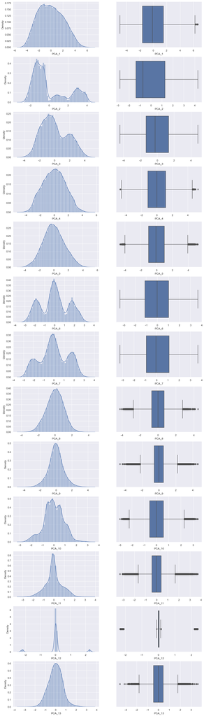

```python
#Checking Distribution of data after PCA
all_col_x = df.select_dtypes(include=np.number).columns.tolist()
#all_col_x.remove('Customer_Id')
sns.set(font_scale=1.0)

a=1
plt.figure(figsize=(15,80))
for i in all_col_x:
        plt.subplot(18,2,a)
        sns.distplot(df[i])
        #plt.title("Histogram for:" + i)
        plt.subplot(18,2,a+1)
        sns.boxplot(df[i])
       # plt.title("Boxplot for:" + i)
        a+=2
```

**Observation:**

- Although PCA ensures variables are independent by looking those plots we can observe a great amount of outliers.
- Logistic regression model may perform poorly due the existence of those outliers however others models (tree-based models) will not be affected.
- Since most of sofisticated models for instance Adaboost, Gradient Boost and XG boost are tree-based models no futher pre-processing will be required since outliers will not affect the performance of such models and it is very likelly they will perform better in comparison with Logistic Regression.

### **1.1. Splitting Dataset, Strategy to Handle the Big Amount of Data**

**Important Information:**

- (1) Since current dataset have 1,181,921 datapoints and I do not have cloud based services or paralell Computing resources avaiable, in this project 10% of the dataset will be cut from original without replacement for further statistical test. As a golden rule removing 10% of the original dataset does not affect the characteristics of the population (dataset).
- (2) This 10% dataset sample will be used for model bulding part and most importantly hyper tuning.
- (3) After model tuning part, the 3 best models with model pre-defined hyper parameters will be used and passed in the full dataset 100%.
- (4) The best model will be selected.

```python
# Get 10 % of rows from the df
df10 = df.sample(frac =.1)
```

```python
#Checking dataset
df10.head()
```

|  | PCA_1 | PCA_2 | PCA_3 | PCA_4 | PCA_5 | PCA_6 | PCA_7 | PCA_8 | PCA_9 | PCA_10 | PCA_11 | PCA_12 | PCA_13 | Satisfaction |
| --- | --- | --- | --- | --- | --- | --- | --- | --- | --- | --- | --- | --- | --- | --- |
| 203683 | 3.406 | 2.704 | -0.758 | -0.605 | -1.017 | -0.184 | -1.397 | -0.688 | -0.344 | 0.468 | -0.857 | 0.061 | -0.027 | neutral or dissatisfied |
| 211435 | 0.503 | -1.417 | -0.084 | 0.147 | -0.450 | -0.057 | -1.570 | 0.018 | -1.138 | -1.293 | -0.579 | 0.003 | 1.522 | satisfied |
| 195795 | 1.360 | -1.160 | -2.971 | -0.044 | 0.866 | 2.579 | 0.411 | 1.078 | 1.194 | 0.497 | -0.107 | -0.019 | 0.887 | satisfied |
| 154281 | 2.621 | -2.240 | 1.337 | 1.729 | -4.031 | 1.304 | 1.537 | -0.207 | 0.431 | 0.300 | 0.484 | -0.006 | 0.161 | neutral or dissatisfied |
| 165795 | -1.568 | 0.876 | 3.827 | 0.433 | -0.817 | -1.967 | 0.013 | 0.981 | -0.346 | -0.297 | -0.374 | 2.246 | 0.786 | satisfied |

```python
#Checking dataset shape
df10.shape
```

```
(9092, 14)
```

```python
#Conserve Original Dataset
df_o = df.copy()
```

```python
#Including indexes in a list to drop from original dataframe
index_list = df10.index.tolist()
```

```python
#Dropping samples from original dataset
df = df.drop(index=index_list)
```

**1.1.1 Statistical Test Motivation:**

- In order to make sure the probability distribution on the sample matches the probability distribution on the population a t-test (two-tailed) will be performed.
  - t-test explained: A t-test is a statistical test that is used to compare the means of two groups.

**1.1.2 t-test Assumptions:**

- Independence of the observations: The slicing created previously made sure that.
- No significant outliers in the two groups: PCA_2 was not taken in account.
- Normality. the data for each group should be approximately normally distributed: First and second group were verified thru plots.
- Homogeneity of variances. the variance of the outcome variable should be equal in each group. This assumption must be tested.

**Hypothesys Test Definition**

- **Null Hypothesis = Ho =** "Mean of the sample is equal to the mean of the population."
- **Null Alternate = Ha =** "Mean of the sample is different to the mean of the population."
  - It was selected **significance level = 0.05**

#### **1.1.3 t-test (two-tailed) execution**

#### **1.1.3.1 Validating Homogeneity of Variances**

```python
#Checking variance assumption
print(df['PCA_1'].var())
print(df10['PCA_1'].var())
print(df['PCA_6'].var())
print(df10['PCA_6'].var())
print(df['PCA_9'].var())
print(df10['PCA_9'].var())
```

```
4.231624715191889
4.323287811458318
2.0156628339757203
2.0621599861651583
0.8912905100212984
0.9026676960062764
```

**Observation:**

- With a variance varying at max of 0.1 it will be assumed variance are the same for each those two groups

```python
import scipy.stats as stats
```

```python
# Randomly selecing variable to be checked
x = np.array(df['PCA_1'])  # Selecting a random variable
y = np.array(df10['PCA_1']) # Selecting a random variable

t, p_value  = stats.ttest_ind(x,y)
```

```python
# For two tailed t-test let's check its p-value
print("Tstat:",t,"P-value:",p_value)
```

```
Tstat: -1.695224934550905 P-value: 0.0900361828140794
```

```python
# Randomly selecing variable to be checked
x = np.array(df['PCA_6'])  # Selecting a random variable
y = np.array(df10['PCA_6']) # Selecting a random variable

t, p_value  = stats.ttest_ind(x,y)
```

```python
# For two tailed t-test let's check its p-value
print("Tstat:",t,"P-value:",p_value)
```

```
Tstat: -0.1387407205556703 P-value: 0.8896553461989865
```

```python
# Randomly selecing variable to be checked
x = np.array(df['PCA_9'])  # Selecting a random variable
y = np.array(df10['PCA_9']) # Selecting a random variable

t, p_value  = stats.ttest_ind(x,y)
```

```python
# For two tailed t-test let's check its p-value
print("Tstat:",t,"P-value:",p_value)
```

```
Tstat: 0.7752002488679861 P-value: 0.4382233573938765
```

**Conclusion:**

- Randomly selecting 3 variables and comparing the sample - 10% of the original dataset with the population (full dataset) the hypothesys t-test failed to reject null hypothesys.
- Statistically speaking the sample is a good representation of the population: all the p-values are greater than the significance level = 0.05

```python
#Splitting target variable
X = df10.drop(['Satisfaction'],axis=1)
y = df10['Satisfaction'].apply(lambda x : 0 if x=='neutral or dissatisfied' else 1)
```

```python
# Splitting data into training and test set:
X_train, X_test, y_train, y_test = train_test_split(X, y, test_size=0.3, random_state=7,stratify=y)
print(X_train.shape, X_test.shape)
```

```
(6364, 13) (2728, 13)
```

### **1.2. Building Models**

#### 1.2.1 Model evaluation criterion

#### - Model can make wrong predictions as:

1. Predicting a customer is satisfied but customer is not satisfied.
   - Impact in business:
     - lose a valuable customer or asset since the company will never identify customer level of satisfaction
     - marketing team might incorretly include this customer in regular marketing campaigns group whereas the correct group would be for custumers who need attention for a possible customer retention campaigns.
2. Predicting a customer is not satisfied but in fact customer is satisfied.
   - Impact in business:
     - Marketing team could spend extra resources in customer retention campaigns for this customer but it would not be necessary since custumer is already satisfied.
     - This error could contribute to unplanned revenue growth, the consequence of such error may positively contribute in revenue since customer may not be counted as loyal or recurrent revenue but in fact they will comeback.

#### - Which case is more important?

- The main goal of Falcon airlines is towards the parameters importance for passenger satisfaction and since nor cost reduction nor better marketing expenditure were mentioned during project review: Predicting a customer is satisfied but customer is not satisfied will be the focus error to be reduced.

**Precision =** True Positive / (True Positive + False Positive)

#### - How to reduce this loss i.e need to reduce False Positives?

- The metrics choosen was `Prediction` to be maximized, greater the Precision higher the chances of minimizing false positives. Hence, the focus should be on increasing Prediction metrics or minimizing the false positive or in other words identifying the true positives so that Falcon Airlines can lower the risk of loose customers by putting the right resources towards the risk customers (dissatisfied ones).

**Fist, let's create two functions to calculate different metrics and confusion matrix, so that we don't have to use the same code repeatedly for each model.**

```python
def get_metrics_score(model,train,test,train_y,test_y,flag=True):
    '''
    model : classifier to predict values of X

    '''
    # defining an empty list to store train and test results
    score_list=[]

    pred_train = model.predict(train)
    pred_test = model.predict(test)

    train_precision = metrics.precision_score(train_y,pred_train)
    test_precision = metrics.precision_score(test_y,pred_test)

    score_list.extend((train_precision,test_precision))

    # If the flag is set to True then only the following print statements will be dispayed. The default value is set to True.
    if flag == True:
        print("Precision on training set : ",metrics.precision_score(train_y,pred_train))
        print("Precision on test set : ",metrics.precision_score(test_y,pred_test))

    return score_list # returning the list with train and test scores
```

```python
##  Function to calculate precision score
def get_precision_score(model,flag=True):
    '''
    model : classifier to predict values of X

    '''
    b = []  # defining an empty list to store train and test results
    pred_train = model.predict(X_train)
    pred_test = model.predict(X_test)
    train_precision = metrics.precision_score(y_train,pred_train)
    test_precision = metrics.precision_score(y_test,pred_test)
    b.append(train_precision) # adding train precision to list
    b.append(test_precision) # adding test precision to list
    if flag == True: # If the flag is set to True then only the following print statements will be dispayed
        print("Precision on training set : ",metrics.precision_score(y_train,pred_train))
        print("Precision on test set : ",metrics.precision_score(y_test,pred_test))

    return b # returning the list with train and test scores
```

```python
## Defining a function for better visualization of confusion matrix

from sklearn.metrics import classification_report,confusion_matrix
#mat_train = confusion_matrix(y_train,pred_train)


def make_confusion_matrix(y_actual,y_predict,labels=[1, 0]):
    '''
    y_predict: prediction of class
    y_actual : ground truth
    '''
    cm=confusion_matrix( y_predict,y_actual, labels=[1, 0])
    df_cm = pd.DataFrame(cm, index = [i for i in ["1","0"]],
                  columns = [i for i in ['1','0']])
    group_counts = ["{0:0.0f}".format(value) for value in
                cm.flatten()]
    group_percentages = ["{0:.2%}".format(value) for value in
                         cm.flatten()/np.sum(cm)]
    labels = [f"{v1}\n{v2}" for v1, v2 in
              zip(group_counts,group_percentages)]
    labels = np.asarray(labels).reshape(2,2)
    plt.figure(figsize = (7,5))
    sns.heatmap(df_cm, annot=labels,fmt='')
    plt.ylabel('True label')
    plt.xlabel('Predicted label')
```

**1.2.2 Model 1: Logistic Regression**

**Important:**

- Regression model are highly affected by multi-collinearity. Multi-collinearity happens when independent variables in the regression model are highly correlated to each other. It makes it hard to interpret of model and also creates an overfitting problems.
- In this study VIF (Variance Inflation factor) will be used to measure Multi-collinearity.

```python
#Adding a constant feature required to run the model
num_feature_set = X.copy()
from statsmodels.tools.tools import add_constant
num_feature_set = add_constant(num_feature_set)
```

```python
#Checking VIF
from statsmodels.stats.outliers_influence import variance_inflation_factor
vif_series1 = pd.Series([variance_inflation_factor(num_feature_set.values,i) for i in range(num_feature_set.shape[1])],index=num_feature_set.columns)
print('Series before feature selection: \n\n{}\n'.format(vif_series1))
```

```
Series before feature selection:

const    1.001
PCA_1    1.001
PCA_2    1.001
PCA_3    1.002
PCA_4    1.001
PCA_5    1.001
PCA_6    1.001
PCA_7    1.001
PCA_8    1.001
PCA_9    1.002
PCA_10   1.001
PCA_11   1.001
PCA_12   1.002
PCA_13   1.002
dtype: float64
```

**Observation:**

- VIF has a lower bound of 1, meaning VIF equals 1 has no correlation.
- None of the presented variables are correlated each other, PCA ensured this scenario. Dataset has no multi-collinerarity problems.

```python
#Checking Logistic Regression Results
import statsmodels.api as sm
logit = sm.Logit(y_train, X_train)
lg = logit.fit()

print(lg.summary())
```

```
Optimization terminated successfully.
         Current function value: 0.433515
         Iterations 6
                           Logit Regression Results
==============================================================================
Dep. Variable:           Satisfaction   No. Observations:                 6364
Model:                          Logit   Df Residuals:                     6351
Method:                           MLE   Df Model:                           12
Date:                Mon, 09 Aug 2021   Pseudo R-squ.:                  0.3701
Time:                        21:41:32   Log-Likelihood:                -2758.9
converged:                       True   LL-Null:                       -4380.2
Covariance Type:            nonrobust   LLR p-value:                     0.000
==============================================================================
                 coef    std err          z      P>|z|      [0.025      0.975]
------------------------------------------------------------------------------
PCA_1         -0.8949      0.022    -40.164      0.000      -0.939      -0.851
PCA_2          0.1051      0.018      5.763      0.000       0.069       0.141
PCA_3         -0.0679      0.019     -3.641      0.000      -0.104      -0.031
PCA_4          0.0344      0.022      1.598      0.110      -0.008       0.077
PCA_5          0.0807      0.022      3.670      0.000       0.038       0.124
PCA_6         -0.1853      0.023     -7.975      0.000      -0.231      -0.140
PCA_7          0.1961      0.024      8.113      0.000       0.149       0.243
PCA_8          0.4835      0.032     15.307      0.000       0.422       0.545
PCA_9         -0.4721      0.035    -13.353      0.000      -0.541      -0.403
PCA_10         0.1468      0.038      3.889      0.000       0.073       0.221
PCA_11        -0.0884      0.041     -2.178      0.029      -0.168      -0.009
PCA_12         0.0487      0.044      1.119      0.263      -0.037       0.134
PCA_13         0.3320      0.048      6.908      0.000       0.238       0.426
==============================================================================
```

**P-Values Interpretation:**

- A predictor that has a low p-value (< 0.05) is likely to be a meaningful addition to your model because changes in the predictor's value are related to changes in the response variable.
- Conversely, a larger (insignificant) p-value suggests that changes in the predictor are not associated with changes in the response.
- Any p-value greater than (0.05) means the associated variable is not statistically significant.

```python
# Let's check accuracy and recall for this model

pred_train = lg.predict(X_train)
pred_test = lg.predict(X_test)

pred_train = np.round(pred_train)
pred_test = np.round(pred_test)

print('Precision on train data:',precision_score(y_train, pred_train) )
print('Precision on test data:',precision_score(y_test, pred_test))

Lg_train = precision_score(y_train, pred_train)
Lg_test = precision_score(y_test, pred_test)
```

```
Precision on train data: 0.8528428093645485
Precision on test data: 0.8596739900779589
```

**Observation:**

- **First Model without any modification** does not show any sign of overfitting but its performance may be lower than others models.
- Precision on Test Data = 85.96.
- Next model, variable 'PCA 12' will be droped since it has a p-value=0.263

```python
#Dropping variable with the greatest p-value
X_train1 = X_train.drop('PCA_12', axis = 1)
X_test1 = X_test.drop('PCA_12', axis = 1)

logit1 = sm.Logit(y_train, X_train1)
lg1 = logit1.fit()

print(lg1.summary())
```

```
Optimization terminated successfully.
         Current function value: 0.433613
         Iterations 6
                           Logit Regression Results
==============================================================================
Dep. Variable:           Satisfaction   No. Observations:                 6364
Model:                          Logit   Df Residuals:                     6352
Method:                           MLE   Df Model:                           11
Date:                Mon, 09 Aug 2021   Pseudo R-squ.:                  0.3700
Time:                        20:11:42   Log-Likelihood:                -2759.5
converged:                       True   LL-Null:                       -4380.2
Covariance Type:            nonrobust   LLR p-value:                     0.000
==============================================================================
                 coef    std err          z      P>|z|      [0.025      0.975]
------------------------------------------------------------------------------
PCA_1         -0.8948      0.022    -40.172      0.000      -0.938      -0.851
PCA_2          0.1053      0.018      5.776      0.000       0.070       0.141
PCA_3         -0.0683      0.019     -3.660      0.000      -0.105      -0.032
PCA_4          0.0339      0.022      1.577      0.115      -0.008       0.076
PCA_5          0.0806      0.022      3.664      0.000       0.037       0.124
PCA_6         -0.1857      0.023     -7.994      0.000      -0.231      -0.140
PCA_7          0.1959      0.024      8.106      0.000       0.149       0.243
PCA_8          0.4835      0.032     15.307      0.000       0.422       0.545
PCA_9         -0.4720      0.035    -13.348      0.000      -0.541      -0.403
PCA_10         0.1475      0.038      3.908      0.000       0.074       0.221
PCA_11        -0.0881      0.041     -2.172      0.030      -0.168      -0.009
PCA_13         0.3310      0.048      6.889      0.000       0.237       0.425
==============================================================================
```

```python
# Let's check accuracy and recall for this model

pred_train1 = lg1.predict(X_train1)
pred_test1 = lg1.predict(X_test1)

pred_train1 = np.round(pred_train1)
pred_test1 = np.round(pred_test1)


print('Precision on train data:',precision_score(y_train, pred_train1) )
print('Precision on test data:',precision_score(y_test, pred_test1))
```

```
Precision on train data: 0.8532806804374241
Precision on test data: 0.8605974395448079
```

**Observation:**

- Model does not shows any sign of overfitting but its performance may be lower than others models.
- Precision on Test Data = 86.06. No improvements by dropping variable
- Next model, variable 'PCA 4' will be droped since it has a p-value=0.115

```python
#Dropping variable with the greatest p-value
X_train2 = X_train1.drop('PCA_4', axis = 1)
X_test2 = X_test1.drop('PCA_4', axis = 1)

logit2 = sm.Logit(y_train, X_train2)
lg2 = logit2.fit()

print(lg2.summary())
```

```
Optimization terminated successfully.
         Current function value: 0.433809
         Iterations 6
                           Logit Regression Results
==============================================================================
Dep. Variable:           Satisfaction   No. Observations:                 6364
Model:                          Logit   Df Residuals:                     6353
Method:                           MLE   Df Model:                           10
Date:                Mon, 09 Aug 2021   Pseudo R-squ.:                  0.3697
Time:                        20:11:53   Log-Likelihood:                -2760.8
converged:                       True   LL-Null:                       -4380.2
Covariance Type:            nonrobust   LLR p-value:                     0.000
==============================================================================
                 coef    std err          z      P>|z|      [0.025      0.975]
------------------------------------------------------------------------------
PCA_1         -0.8955      0.022    -40.186      0.000      -0.939      -0.852
PCA_2          0.1058      0.018      5.809      0.000       0.070       0.142
PCA_3         -0.0687      0.019     -3.687      0.000      -0.105      -0.032
PCA_5          0.0802      0.022      3.643      0.000       0.037       0.123
PCA_6         -0.1851      0.023     -7.967      0.000      -0.231      -0.140
PCA_7          0.1955      0.024      8.092      0.000       0.148       0.243
PCA_8          0.4820      0.032     15.268      0.000       0.420       0.544
PCA_9         -0.4718      0.035    -13.328      0.000      -0.541      -0.402
PCA_10         0.1463      0.038      3.877      0.000       0.072       0.220
PCA_11        -0.0865      0.041     -2.132      0.033      -0.166      -0.007
PCA_13         0.3323      0.048      6.914      0.000       0.238       0.426
==============================================================================
```

```python
# Let's check accuracy and recall for this model
pred_train2 = lg2.predict(X_train2)
pred_test2 = lg2.predict(X_test2)

pred_train2 = np.round(pred_train2)
pred_test2 = np.round(pred_test2)

print('Precision on train data:',precision_score(y_train, pred_train2) )
print('Precision on test data:',precision_score(y_test, pred_test2))
```

```
Precision on train data: 0.854578643139641
Precision on test data: 0.8612880396319886
```

**Observation:**

- Model did not show any sign of overfitting, the difference between test and train was reduced.
- Precision on Test Data = 86.12. An improvement of .06 was found by removing variables: PCA_12 And PCA_4.
- No more variables to be dropped since most p-values are lower than 0.05

**Conclusion:**

**1.2.3 Model 1: Logistic Regression (AUC-ROC) using optimal threshold**

**Prediction on Train data**

```python
#Defining variables for confusion matrix  function
pred_train = lg.predict(X_train)
pred_train = np.round(pred_train)
```

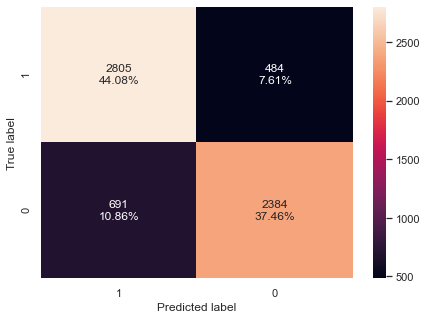

```python
#Confusion matrix on Train Data
make_confusion_matrix(y_train,pred_train)
```

**Predicting on Test Data**

```python
#Defining variables for confusion matrix  function
pred_test0 = lg.predict(X_test)
pred_test0 = np.round(pred_test0)
```

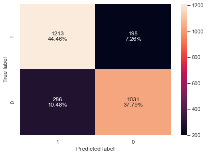

```python
# Creating confusion matrix
make_confusion_matrix(y_test,pred_test0)
```

```python
#Precision with a threhold of 0.5
print('Precision on train data:',precision_score(y_train, pred_train) )
print('Precision on test data:',precision_score(y_test, pred_test0))
```

```
Precision on train data: 0.8528428093645485
Precision on test data: 0.8596739900779589
```

**Observation:**

- Model did not show any signs of overfitting, the difference between test and train was reduced.
- Precision on Test Data = 0.860 kept the same. This technic did not add much value.

**1.2.3.1 AUC-ROC Curve**

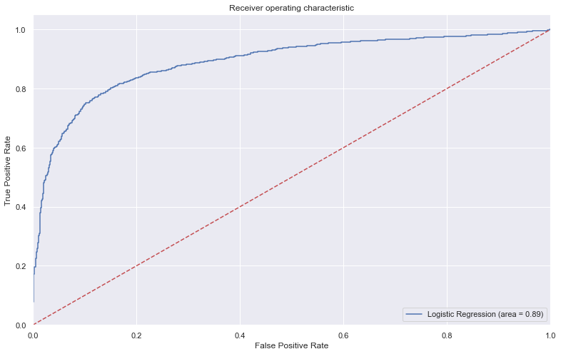

```python
logit_roc_auc = roc_auc_score(y_test, lg.predict(X_test))
fpr, tpr, thresholds = roc_curve(y_test, lg.predict(X_test))
plt.figure(figsize=(13,8))
plt.plot(fpr, tpr, label='Logistic Regression (area = %0.2f)' % logit_roc_auc)
plt.plot([0, 1], [0, 1],'r--')
plt.xlim([0.0, 1.0])
plt.ylim([0.0, 1.05])
plt.xlabel('False Positive Rate')
plt.ylabel('True Positive Rate')
plt.title('Receiver operating characteristic')
plt.legend(loc="lower right")
plt.savefig('Log_ROC')
plt.show()
```

**Important:**

- The ROC curve shows a trade-off between TPR and FPR (or false negatives and false positives). It plots TPR vs FPR at different thresholds.
- The idea is to find an option threshold where TPR is maximazed and FPR is minimazed.
- AUC (area under the curve), represents a degree or measure of separability. It tells us how much the model is capable of distinguishing between classes. It ranges from 0 to 1. A model whose predictions are 100% right has an AUC =1
- Results demonstrated AUC = 0.89 which can be considered a good result.

#### **1.2.3.2 Choosing Optimal threshold**

```python
pred_train = lg.predict(X_train)
# The optimal cut off would be where tpr is high and fpr is low
fpr, tpr, thresholds = roc_curve(y_train, pred_train)

optimal_idx = np.argmax(tpr - fpr)
optimal_threshold = thresholds[optimal_idx]
print(optimal_threshold)
```

```
0.5122461740681653
```

**Observation:**

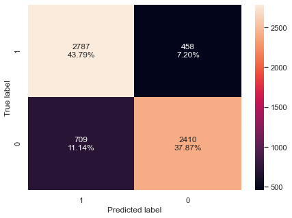

```python
# plotting confusion matrix using optimal threshold
y_pred_tr = (lg.predict(X_train)>optimal_threshold).astype(int)
y_pred_ts = (lg.predict(X_test)>optimal_threshold).astype(int)
make_confusion_matrix(y_train,y_pred_tr )
```

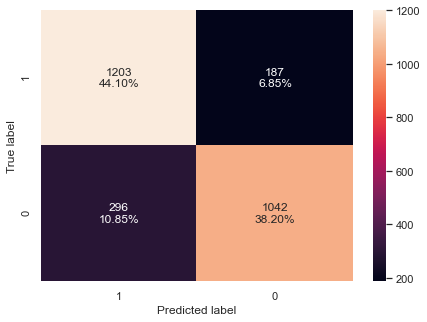

```python
# let us make confusion matrix on test set
make_confusion_matrix(y_test,y_pred_ts)
```

```python
#Precision with a threhold of 0.49
print('Precision on train data:',precision_score(y_train,y_pred_tr) )
print('Precision on test data:',precision_score(y_test,y_pred_ts))

Lg_opt_train = precision_score(y_train,y_pred_tr)
Lg_opt_test = precision_score(y_test,y_pred_ts)
```

```
Precision on train data: 0.8588597842835131
Precision on test data: 0.8654676258992806
```

**Conclusion:**

**1.2.4 Checking for unbalanced data**

```python
print("Before UpSampling, counts of label 'Yes': {}".format(sum(y_train==1)))
print("Before UpSampling, counts of label 'No': {} \n".format(sum(y_train==0)))
```

```
Before UpSampling, counts of label 'Yes': 3496
Before UpSampling, counts of label 'No': 2868
```

**Conclusion:**

- The minority class with 45% of the dataset does not represent an unbalanced dataset. I could not find information to support what would be a percentage threshold to be considered unbalanced but I can certainly say 10% percent difference should be a normal difference that do not represent a significant unbalanced dataset problem.

**1.2.5 Bagging and Boosting**

**Important:**

- Bagging and boosting (Ensemble Methods):
  - They are similar both are ensemble techniques, where a set of weak learners are combined to create a strong learner that obtains better performance than a single one.
  - Bagging helps to decrease the model’s variance.
  - Boosting helps to decrease the model’s bias.
  - These methods are designed to improve the stability and the accuracy of Machine Learning algorithms. Combinations of multiple classifiers decrease variance, especially in the case of unstable classifiers, and may produce a more reliable classification than a single classifier.
- Stratified K-Folds cross-validator:
  - It provides dataset indices to split data in train/validation sets. Split dataset into k consecutive folds (without shuffling by default) keeping distribution of both classes in each fold same as the target variable. Each fold is then used once as a validation while the k - 1 remaining folds form the training set.

**Process Detail:**

- Build different models using KFold and cross_val_score with pipelines and tune the best model using GridSearchCV and RandomizedSearchCV**

```python
%%time

models = []  # Empty list to store all the models

# Appending pipelines for each model into the list

models.append(
    (
        "DTREE",
        Pipeline(
            steps=[
                ("scaler", StandardScaler()),
                ("decision_tree", DecisionTreeClassifier(random_state=1,)),
            ]
        ),
    )
)


models.append(
    (
        "Bagging",
        Pipeline(
            steps=[
                ("scaler", StandardScaler()),
                ("random_forest", BaggingClassifier(random_state=1)),
            ]
        ),
    )
)


models.append(
    (
        "RF",
        Pipeline(
            steps=[
                ("scaler", StandardScaler()),
                ("random_forest", RandomForestClassifier(random_state=1)),
            ]
        ),
    )
)

models.append(
    (
        "ADB",
        Pipeline(
            steps=[
                ("scaler", StandardScaler()),
                ("adaboost", AdaBoostClassifier(random_state=1)),
            ]
        ),
    )
)


models.append(
    (
        "GBM",
        Pipeline(
            steps=[
                ("scaler", StandardScaler()),
                ("gradient_boosting", GradientBoostingClassifier(random_state=1)),
            ]
        ),
    )
)


models.append(
    (
        "XGB",
        Pipeline(
            steps=[
                ("scaler", StandardScaler()),
                ("xgboost", XGBClassifier(random_state=1,eval_metric='logloss')),
            ]
        ),
    )
)

results = []  # Empty list to store all model's CV scores
names = []  # Empty list to store name of the models

# loop through all models to get the mean cross validated score
for name, model in models:
    scoring = "precision"
    kfold = StratifiedKFold(
        n_splits=5, shuffle=True, random_state=1
    )  # Setting number of splits equal to 5
    cv_result = cross_val_score(
        estimator=model, X=X_train, y=y_train, scoring=scoring, cv=kfold
    )
    results.append(cv_result)
    names.append(name)
    print("{}: {}".format(name, cv_result.mean() * 100))
```

```
DTREE: 81.82883975301445
Bagging: 88.0861103928525
RF: 89.16408043178969
ADB: 83.69949732592016
GBM: 87.80644922810754
XGB: 88.9577162517292
Wall time: 26.5 s
```

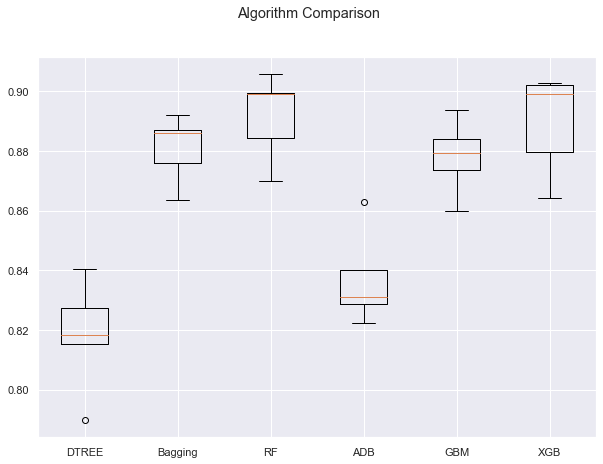

```python
# Plotting boxplots for CV scores of all models defined above
fig = plt.figure(figsize=(10, 7))

fig.suptitle("Algorithm Comparison")
ax = fig.add_subplot(111)

plt.boxplot(results)
ax.set_xticklabels(names)

plt.show()
```

# **Model Selection Conclusion:**

**- These 4 models** selected previously will be used for Hypertuning as an attempt to better tailor the defaut model and their hyperparameters to the characteristics of the dataset in study.

**1.2.6 Hyperparameter Tuning**

**1.2.6.1 Hyperparameter Tuning - BaggingClassifier**

**1.2.6.1.1 GridSerach CV - BaggingClassifier**

```python
%%time

# Creating pipeline
pipe = make_pipeline(StandardScaler(), BaggingClassifier(random_state=1))

# Parameter grid to pass in GridSearchCV

param_grid = {
              'baggingclassifier__max_samples': [0.7,0.8,0.9,1],
              'baggingclassifier__max_features': [0.7,0.8,0.9,1],
              'baggingclassifier__n_estimators' : [10,20,30,40,50],
             }

# Type of scoring used to compare parameter combinations
scorer = metrics.make_scorer(metrics.precision_score)

# Calling GridSearchCV
grid_cv = GridSearchCV(estimator=pipe, param_grid=param_grid, scoring=scorer, cv=5, n_jobs = -1)

# Fitting parameters in GridSeachCV
grid_cv.fit(X_train, y_train)

print(
    "Best Parameters:{} \nScore: {}".format(grid_cv.best_params_, grid_cv.best_score_)
)
```

```
Best Parameters:{'baggingclassifier__max_features': 0.7, 'baggingclassifier__max_samples': 0.8, 'baggingclassifier__n_estimators': 40}
Score: 0.8946279996199002
Wall time: 1min 6s
```

```python
# Creating new pipeline with best parameters
bagg_tuned1 = make_pipeline(
    StandardScaler(),
    BaggingClassifier(
        max_features=0.7,
        max_samples=0.8,
        random_state=1,
        n_estimators=40,
    ),
)

# Fit the model on training data
bagg_tuned1.fit(X_train, y_train)
```

```
Pipeline(steps=[('standardscaler', StandardScaler()),
                ('baggingclassifier',
                 BaggingClassifier(max_features=0.7, max_samples=0.8,
                                   n_estimators=40, random_state=1))])
```

```python
def make_confusion_matrix2(model,y_actual,labels=[1, 0]):
    '''
    model : classifier to predict values of X
    y_actual : ground truth

    '''
    y_predict = model.predict(X_test)
    cm=metrics.confusion_matrix( y_actual, y_predict, labels=[0, 1])
    df_cm = pd.DataFrame(cm, index = [i for i in ["Actual - No","Actual - Yes"]],
                  columns = [i for i in ['Predicted - No','Predicted - Yes']])
    group_counts = ["{0:0.0f}".format(value) for value in
                cm.flatten()]
    group_percentages = ["{0:.2%}".format(value) for value in
                         cm.flatten()/np.sum(cm)]
    labels = [f"{v1}\n{v2}" for v1, v2 in
              zip(group_counts,group_percentages)]
    labels = np.asarray(labels).reshape(2,2)
    plt.figure(figsize = (10,7))
    sns.heatmap(df_cm, annot=labels,fmt='')
    plt.ylabel('True label')
    plt.xlabel('Predicted label')
```

```
Precision on training set :  0.9977123248498713
Precision on test set :  0.8988919667590027
```

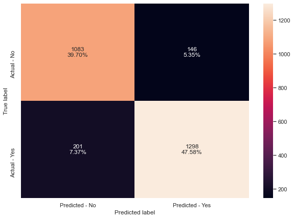

```python
# Calculating different metrics
get_metrics_score(bagg_tuned1,X_train,X_test,y_train,y_test)

# Creating confusion matrix
make_confusion_matrix2(bagg_tuned1, y_test)
```

- The precision on test dataset has increased to 89.88 as compared to the result from cross validation 88.08 with default parameters.
- The model is overfitting the training data.

**1.2.6.1.2 RandomizedSearchCV - BaggingClassifier**

```python
%%time

# Creating pipeline
pipe = make_pipeline(StandardScaler(), BaggingClassifier(random_state=1))

# Parameter grid to pass in RandomSearchCV
param_grid = {
              'baggingclassifier__max_samples': [0.7,0.8,0.9,1],
              'baggingclassifier__max_features': [0.7,0.8,0.9,1],
              'baggingclassifier__n_estimators' : [10,20,30,40,50],
             }

# Type of scoring used to compare parameter combinations
scorer = metrics.make_scorer(metrics.precision_score)

#Calling RandomizedSearchCV
randomized_cv = RandomizedSearchCV(estimator=pipe, param_distributions=param_grid, n_jobs = -1, n_iter=50, scoring=scorer, cv=5, random_state=1)

#Fitting parameters in RandomizedSearchCV
randomized_cv.fit(X_train,y_train)

print("Best parameters are {} with CV score={}:" .format(randomized_cv.best_params_,randomized_cv.best_score_))
```

```
Best parameters are {'baggingclassifier__n_estimators': 40, 'baggingclassifier__max_samples': 0.8, 'baggingclassifier__max_features': 0.7} with CV score=0.8946279996199002:
Wall time: 38.8 s
```

```python
# Creating new pipeline with best parameters
bagg_tuned2 = make_pipeline(
    StandardScaler(),
    BaggingClassifier(
        max_features=0.8,
        random_state=1,
        max_samples=0.7,
        n_estimators=40
    ),
)

# Fit the model on training data
bagg_tuned2.fit(X_train, y_train)
```

```
Pipeline(steps=[('standardscaler', StandardScaler()),
                ('baggingclassifier',
                 BaggingClassifier(max_features=0.8, max_samples=0.7,
                                   n_estimators=40, random_state=1))])
```

```
Precision on training set :  0.9956983080011471
Precision on test set :  0.8861185983827493
```

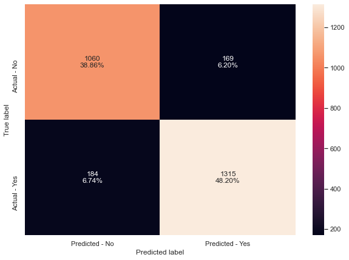

```python
# Calculating different metrics
get_metrics_score(bagg_tuned2,X_train,X_test,y_train,y_test)

# Creating confusion matrix
make_confusion_matrix2(bagg_tuned2, y_test)
```

- Grid search took significantly longer time than random search.
- The parameters from random search to grid search did not change.
- Model is overfitting train set for the parameters given by random search.
- The precision on test dataset has decreased to 88.61 as compared to the result from grid search 89.88 with default parameters.

**1.2.6.2 Hyperparameter Tuning - GradientBoost**

**1.2.6.2.1 GridSerach CV - GradientBoost**

```python
%%time

# Creating pipeline
pipe = make_pipeline(StandardScaler(), GradientBoostingClassifier(random_state=1))

# Parameter grid to pass in GridSearchCV
param_grid = {
    "gradientboostingclassifier__init": [AdaBoostClassifier(random_state=1),DecisionTreeClassifier(random_state=1)],
    "gradientboostingclassifier__n_estimators": np.arange(75,150,25),
    "gradientboostingclassifier__learning_rate": [0.1, 0.01, 0.2, 0.05, 1],
    "gradientboostingclassifier__subsample":[0.5,0.7,1],
    "gradientboostingclassifier__max_features":[0.5,0.7,1],
}

# Type of scoring used to compare parameter combinations
scorer = metrics.make_scorer(metrics.precision_score)

# Calling GridSearchCV
grid_cv = GridSearchCV(estimator=pipe, param_grid=param_grid, scoring=scorer, cv=5, n_jobs = -1)

# Fitting parameters in GridSeachCV
grid_cv.fit(X_train, y_train)

print(
    "Best Parameters:{} \nScore: {}".format(grid_cv.best_params_, grid_cv.best_score_)
)
```

```
Best Parameters:{'gradientboostingclassifier__init': AdaBoostClassifier(random_state=1), 'gradientboostingclassifier__learning_rate': 0.1, 'gradientboostingclassifier__max_features': 0.7, 'gradientboostingclassifier__n_estimators': 100, 'gradientboostingclassifier__subsample': 0.7}
Score: 0.8855693094723055
Wall time: 6min 26s
```

```python
# Creating new pipeline with best parameters
gbc_tuned1 = make_pipeline(
    StandardScaler(),
    GradientBoostingClassifier(
        init=AdaBoostClassifier(random_state=1),
        learning_rate=0.1,
        max_features=0.7,
        n_estimators=100,
        subsample=0.7,
        random_state=1,
    ),
)

# Fit the model on training data
gbc_tuned1.fit(X_train, y_train)
```

```
Pipeline(steps=[('standardscaler', StandardScaler()),
                ('gradientboostingclassifier',
                 GradientBoostingClassifier(init=AdaBoostClassifier(random_state=1),
                                            max_features=0.7, random_state=1,
                                            subsample=0.7))])
```

```
Precision on training set :  0.9092231597323247
Precision on test set :  0.8819163292847504
```

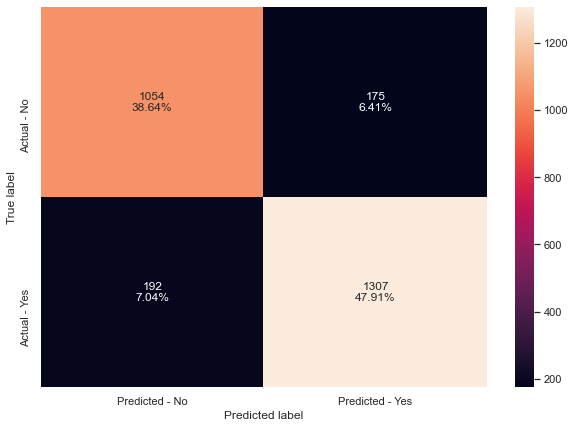

```python
# Calculating different metrics
get_metrics_score(gbc_tuned1,X_train,X_test,y_train,y_test)

# Creating confusion matrix
make_confusion_matrix2(gbc_tuned1, y_test)
```

**1.2.6.2.2 RandomizedSearchCV - GradientBoost**

```python
%%time

#Creating pipeline
pipe=make_pipeline(StandardScaler(),GradientBoostingClassifier(random_state=1))

#Parameter grid to pass in RandomSearchCV
param_grid = {
    "gradientboostingclassifier__init": [AdaBoostClassifier(random_state=1),DecisionTreeClassifier(random_state=1)],
    "gradientboostingclassifier__n_estimators": np.arange(75,150,25),
    "gradientboostingclassifier__learning_rate": [0.1, 0.01, 0.2, 0.05, 1],
    "gradientboostingclassifier__subsample":[0.5,0.7,1],
    "gradientboostingclassifier__max_features":[0.5,0.7,1],
}

# Type of scoring used to compare parameter combinations
scorer = metrics.make_scorer(metrics.precision_score)

#Calling RandomizedSearchCV
randomized_cv = RandomizedSearchCV(estimator=pipe, param_distributions=param_grid, n_iter=50, scoring=scorer, cv=5, random_state=1, n_jobs = -1)

#Fitting parameters in RandomizedSearchCV
randomized_cv.fit(X_train,y_train)

print("Best parameters are {} with CV score={}:" .format(randomized_cv.best_params_,randomized_cv.best_score_))
```

[output not shown]

```python
# Creating new pipeline with best parameters
gbc_tuned2 = make_pipeline(
    StandardScaler(),
    GradientBoostingClassifier(
        init=AdaBoostClassifier(random_state=1),
        learning_rate=0.2,
        max_features=0.5,
        n_estimators=100,
        subsample=0.7,
        random_state=1,
    ),
)

# Fit the model on training data
gbc_tuned2.fit(X_train, y_train)
```

```
Pipeline(steps=[('standardscaler', StandardScaler()),
                ('gradientboostingclassifier',
                 GradientBoostingClassifier(init=AdaBoostClassifier(random_state=1),
                                            learning_rate=0.2, max_features=0.5,
                                            random_state=1, subsample=0.7))])
```

```
Precision on training set :  0.9224985540775015
Precision on test set :  0.8885112168592794
```

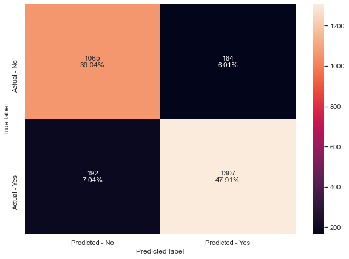

```python
# Calculating different metrics
get_metrics_score(gbc_tuned2,X_train,X_test,y_train,y_test)

# Creating confusion matrix
make_confusion_matrix2(gbc_tuned2, y_test)
```

- The parameters from random search to grid search changed very little.
- Model is not overfitting train set for the parameters given by random search.
- The precision on test dataset has increased to 88.85 as compared to the result from grid search 88.19 with default parameters.

**1.2.6.3 Hyperparameter Tuning - Random Forest**

**1.2.6.3.1 GridSerach CV - Random Forest**

```python
%%time

# Creating pipeline
pipe = make_pipeline(StandardScaler(), RandomForestClassifier(random_state=1))

# Parameter grid to pass in GridSearchCV

param_grid = {
    "randomforestclassifier__n_estimators": [100,150,250,350],
    "randomforestclassifier__min_samples_leaf": np.arange(1, 6),
    "randomforestclassifier__max_features": [np.arange(0.3, 0.6, 0.1),'sqrt','log2'],
    "randomforestclassifier__max_samples": np.arange(0.2, 0.6, 0.1),
}

# Type of scoring used to compare parameter combinations
scorer = metrics.make_scorer(metrics.precision_score)

# Calling GridSearchCV
grid_cv = GridSearchCV(estimator=pipe, param_grid=param_grid, scoring=scorer, cv=5, n_jobs = -1)

# Fitting parameters in GridSeachCV
grid_cv.fit(X_train, y_train)

print(
    "Best Parameters:{} \nScore: {}".format(grid_cv.best_params_, grid_cv.best_score_)
)
```

```
Best Parameters:{'randomforestclassifier__max_features': 'sqrt', 'randomforestclassifier__max_samples': 0.30000000000000004, 'randomforestclassifier__min_samples_leaf': 1, 'randomforestclassifier__n_estimators': 350}
Score: 0.8918330392428
Wall time: 4min 37s
```

```python
# Creating new pipeline with best parameters
rf_tuned1 = make_pipeline(
    StandardScaler(),
    RandomForestClassifier(
        n_estimators=350,
        max_features='sqrt',
        random_state=1,
        max_samples=0.30000000000000004,
        min_samples_leaf=1
    ),
)

# Fit the model on training data
rf_tuned1.fit(X_train, y_train)
```

```
Pipeline(steps=[('standardscaler', StandardScaler()),
                ('randomforestclassifier',
                 RandomForestClassifier(max_features='sqrt',
                                        max_samples=0.30000000000000004,
                                        n_estimators=350, random_state=1))])
```

```
Precision on training set :  0.9571387199536635
Precision on test set :  0.8956043956043956
```

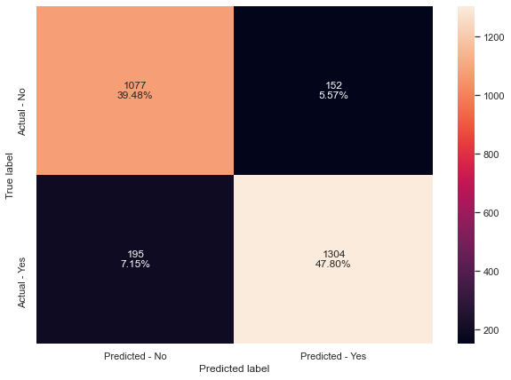

```python
# Calculating different metrics
get_metrics_score(rf_tuned1,X_train,X_test,y_train,y_test)

# Creating confusion matrix
make_confusion_matrix2(rf_tuned1, y_test)
```

- Grid search took a little longer in time to process.
- Model is not overfitting train set and seems to present I reasoanble delta between train and test datasets.
- The precision on test dataset has increased to 89.56 as compared to the result from cross validation 89.16 with default parameters.

**1.2.6.3.2 RandomizedSearchCV - Random Forest**

```python
%%time

# Creating pipeline
pipe = make_pipeline(StandardScaler(), RandomForestClassifier(random_state=1))

# Parameter grid to pass in RandomSearchCV
param_grid = {
    "randomforestclassifier__n_estimators": [100,150,250],
    "randomforestclassifier__min_samples_leaf": np.arange(1, 6),
    "randomforestclassifier__max_features": [np.arange(0.3, 0.6, 0.1),'sqrt','log2'],
    "randomforestclassifier__max_samples": np.arange(0.2, 0.6, 0.1),
}

# Type of scoring used to compare parameter combinations
scorer = metrics.make_scorer(metrics.precision_score)

#Calling RandomizedSearchCV
randomized_cv = RandomizedSearchCV(estimator=pipe, param_distributions=param_grid, n_jobs = -1, n_iter=50, scoring=scorer, cv=5, random_state=1)

#Fitting parameters in RandomizedSearchCV
randomized_cv.fit(X_train,y_train)

print("Best parameters are {} with CV score={}:" .format(randomized_cv.best_params_,randomized_cv.best_score_))
```

```
Best parameters are {'randomforestclassifier__n_estimators': 100, 'randomforestclassifier__min_samples_leaf': 2, 'randomforestclassifier__max_samples': 0.5000000000000001, 'randomforestclassifier__max_features': 'sqrt'} with CV score=0.8914009309761657:
Wall time: 44.7 s
```

```python
# Creating new pipeline with best parameters
rf_tuned2 = make_pipeline(
    StandardScaler(),
    RandomForestClassifier(
        n_estimators=100,
        max_features='sqrt',
        random_state=1,
        max_samples=0.5000000000000001,
        min_samples_leaf=2
    ),
)

# Fit the model on training data
rf_tuned2.fit(X_train, y_train)
```

```
Pipeline(steps=[('standardscaler', StandardScaler()),
                ('randomforestclassifier',
                 RandomForestClassifier(max_features='sqrt',
                                        max_samples=0.5000000000000001,
                                        min_samples_leaf=2, random_state=1))])
```

```
Precision on training set :  0.9654477397063058
Precision on test set :  0.8948805460750853
```

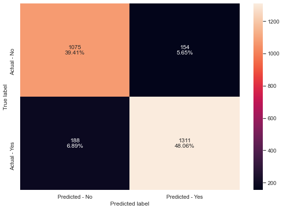

```python
# Calculating different metrics
get_metrics_score(rf_tuned2,X_train,X_test,y_train,y_test)

# Creating confusion matrix
make_confusion_matrix2(rf_tuned2, y_test)
```

- Randomized search took significantly less time than grid search.
- The parameters from random search are different from grid search defaut parameters.
- The model is not overfitting the train data and parameters given by random search resulted in a good performance.
- The precision on test dataset has decreased to 89.48 as compared to the result from grid search 89.56 with default parameters.

**1.2.6.4 Hyperparameter Tuning - XGBoost**

**1.2.6.4.1 GridSerach CV - XGBoost**

```python
XGB_time = %%time

#Creating pipeline
pipe=make_pipeline(StandardScaler(), XGBClassifier(random_state=1,eval_metric='logloss'))

#Parameter grid to pass in GridSearchCV
param_grid={'xgbclassifier__n_estimators':np.arange(50,300,50),'xgbclassifier__scale_pos_weight':[0,1,2,5,10],
            'xgbclassifier__learning_rate':[0.01,0.1,0.2,0.05], 'xgbclassifier__gamma':[0,1,3,5],
            'xgbclassifier__subsample':[0.7,0.8,0.9,1]}

# Type of scoring used to compare parameter combinations
scorer = metrics.make_scorer(metrics.precision_score)

#Calling GridSearchCV
grid_cv = GridSearchCV(estimator=pipe, param_grid=param_grid, scoring=scorer, cv=5, n_jobs = -1)

#Fitting parameters in GridSeachCV
grid_cv.fit(X_train,y_train)


print("Best parameters are {} with CV score={}:" .format(grid_cv.best_params_,grid_cv.best_score_))
```

```
Best parameters are {'xgbclassifier__gamma': 1, 'xgbclassifier__learning_rate': 0.1, 'xgbclassifier__n_estimators': 250, 'xgbclassifier__scale_pos_weight': 1, 'xgbclassifier__subsample': 0.9} with CV score=0.9005907409119995:
Wall time: 1h 19min 57s
```

```python
# Creating new pipeline with best parameters
xgb_tuned1 = make_pipeline(
    StandardScaler(),
    XGBClassifier(
        random_state=1,
        n_estimators=250,
        scale_pos_weight=1,
        subsample=0.9,
        learning_rate=0.1,
        gamma=1,
        eval_metric='logloss',
    ),
)

# Fit the model on training data
xgb_tuned1.fit(X_train, y_train)
```

```
Pipeline(steps=[('standardscaler', StandardScaler()),
                ('xgbclassifier',
                 XGBClassifier(base_score=0.5, booster='gbtree',
                               colsample_bylevel=1, colsample_bynode=1,
                               colsample_bytree=1, eval_metric='logloss',
                               gamma=1, gpu_id=-1, importance_type='gain',
                               interaction_constraints='', learning_rate=0.1,
                               max_delta_step=0, max_depth=6,
                               min_child_weight=1, missing=nan,
                               monotone_constraints='()', n_estimators=250,
                               n_jobs=8, num_parallel_tree=1, random_state=1,
                               reg_alpha=0, reg_lambda=1, scale_pos_weight=1,
                               subsample=0.9, tree_method='exact',
                               validate_parameters=1, verbosity=None))])
```

```
Precision on training set :  0.9971272622809537
Precision on test set :  0.9035498995311454
```

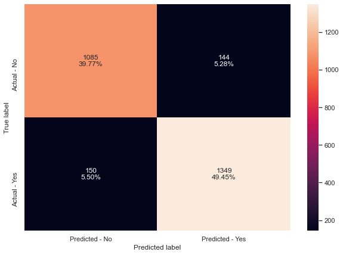

```python
# Calculating different metrics
get_metrics_score(xgb_tuned1,X_train,X_test,y_train,y_test)

# Creating confusion matrix
make_confusion_matrix2(xgb_tuned1, y_test)
```

- Grid search took more time than any other model so far.
- Model is overfitting train set and seems to present a big delta between train and test datasets.
- The precision on test dataset has increased to 90.35 as compared to the result from cross validation 88.95 with default parameters.

**1.2.6.4.2 RandomizedSearchCV - XGBoost**

```python
%%time

#Creating pipeline
pipe=make_pipeline(StandardScaler(),XGBClassifier(random_state=1,eval_metric='logloss'))

#Parameter grid to pass in RandomSearchCV
param_grid={'xgbclassifier__n_estimators':np.arange(50,300,50),'xgbclassifier__scale_pos_weight':[0,1,2,5,10],
            'xgbclassifier__learning_rate':[0.01,0.1,0.2,0.05], 'xgbclassifier__gamma':[0,1,3,5],
            'xgbclassifier__subsample':[0.7,0.8,0.9,1]}

# Type of scoring used to compare parameter combinations
scorer = metrics.make_scorer(metrics.precision_score)

#Calling RandomizedSearchCV
randomized_cv = RandomizedSearchCV(estimator=pipe, param_distributions=param_grid, n_iter=50, n_jobs = -1, scoring=scorer, cv=5, random_state=1)

#Fitting parameters in RandomizedSearchCV
randomized_cv.fit(X_train,y_train)

print("Best parameters are {} with CV score={}:" .format(randomized_cv.best_params_,randomized_cv.best_score_))
```

```
Best parameters are {'xgbclassifier__subsample': 0.7, 'xgbclassifier__scale_pos_weight': 1, 'xgbclassifier__n_estimators': 150, 'xgbclassifier__learning_rate': 0.05, 'xgbclassifier__gamma': 3} with CV score=0.8932590917404912:
Wall time: 2min 35s
```

```python
# Creating new pipeline with best parameters
xgb_tuned2 = Pipeline(
    steps=[
        ("scaler", StandardScaler()),
        (
            "XGB",
            XGBClassifier(
                random_state=1,
                n_estimators=150,
                scale_pos_weight=1,
                learning_rate=0.05,
                gamma=3,
                subsample=0.7,
                eval_metric='logloss',
            ),
        ),
    ]
)
# Fit the model on training data
xgb_tuned2.fit(X_train, y_train)
```

```
Pipeline(steps=[('scaler', StandardScaler()),
                ('XGB',
                 XGBClassifier(base_score=0.5, booster='gbtree',
                               colsample_bylevel=1, colsample_bynode=1,
                               colsample_bytree=1, eval_metric='logloss',
                               gamma=3, gpu_id=-1, importance_type='gain',
                               interaction_constraints='', learning_rate=0.05,
                               max_delta_step=0, max_depth=6,
                               min_child_weight=1, missing=nan,
                               monotone_constraints='()', n_estimators=150,
                               n_jobs=8, num_parallel_tree=1, random_state=1,
                               reg_alpha=0, reg_lambda=1, scale_pos_weight=1,
                               subsample=0.7, tree_method='exact',
                               validate_parameters=1, verbosity=None))])
```

```
Precision on training set :  0.9505813953488372
Precision on test set :  0.9050203527815468
```

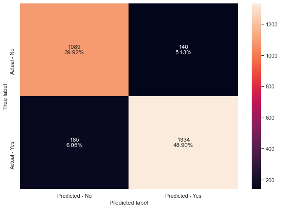

```python
# Calculating different metrics
get_metrics_score(xgb_tuned2,X_train,X_test,y_train,y_test)

# Creating confusion matrix
make_confusion_matrix2(xgb_tuned2, y_test)
```

- Randomized search was very fast in comparison to grid search..
- Model is NOT overfitting train set and seems to present a big delta between train and test datasets.
- The precision on test dataset has increased to 90.50 as compared to the result from grid search 90.35 with default parameters.
- This model has presented a excelent result so far.

```python
#Code to make sound and notebook are done
#import winsound
#frequency = 1500  # Set Frequency To 2500 Hertz
#duration = 1500  # Set Duration To 1000 ms == 1 second
#winsound.Beep(frequency, duration)
```

**1.2.7 Summary of Results, Hypertuning phase**

```python
#del precision_train
#del precision_test
```

```python
# defining list of models
models = [bagg_tuned1,bagg_tuned2,gbc_tuned1,gbc_tuned2,rf_tuned1,rf_tuned2,xgb_tuned1,xgb_tuned2]
```

```python
# defining empty lists to add train and test results
precision_train = []
precision_test = []

# looping through all the models to get the metric score -  Precision
for model in models:

    j = get_metrics_score(model,X_train,X_test,y_train,y_test,False)
    precision_train.append(j[0])
    precision_test.append(j[1])
```

```python
#Adding results from Logistic Regression
precision_train.append(Lg_train)
precision_test.append(Lg_test)
```

```python
#Adding Results from Logistic Regression with Optimal Threshold
precision_train.append(Lg_opt_train)
precision_test.append(Lg_opt_test)
```

```python
#Creating Dataframe to show results from all models
comparison_frame = pd.DataFrame(
    {
        "Model": [
            "Bagging Classifier with GridSearchCV",
            "Bagging Classifier with RandomizedSearchCV",
            "GradientBoost with GridSearchCV",
            "GradientBoost with RandomizedSearchCV",
            "Random Forest with GridSearchCV",
            "Random Forest with RandomizedSearchCV",
            "XGBoost with GridSearchCV",
            "XGBoost with RandomizedSearchCV",
            "Logistic Regression",
            "Logistic Regression w/ Optimal Threshold"

        ],
        "Train_Precision": precision_train,
        "Test_Precision": precision_test,
    }
)

# Sorting models in decreasing order of test recall
comparison_frame
```

|  | Model | Train_Precision | Test_Precision |
| --- | --- | --- | --- |
| 0 | Bagging Classifier with GridSearchCV | 0.998 | 0.899 |
| 1 | Bagging Classifier with RandomizedSearchCV | 0.996 | 0.886 |
| 2 | GradientBoost with GridSearchCV | 0.909 | 0.882 |
| 3 | GradientBoost with RandomizedSearchCV | 0.922 | 0.889 |
| 4 | Random Forest with GridSearchCV | 0.957 | 0.896 |
| 5 | Random Forest with RandomizedSearchCV | 0.965 | 0.895 |
| 6 | XGBoost with GridSearchCV | 0.997 | 0.904 |
| 7 | XGBoost with RandomizedSearchCV | 0.951 | 0.905 |
| 8 | Logistic Regression | 0.853 | 0.860 |
| 9 | Logistic Regression w/ Optimal Threshold | 0.859 | 0.865 |

```python
#creating delta feature column for precision values
comparison_frame['Delta'] = comparison_frame['Train_Precision'] - comparison_frame['Test_Precision']
```

```python
comparison_frame.sort_values(by=['Test_Precision'],ascending=False)
```

|  | Model | Train_Precision | Test_Precision | Delta |
| --- | --- | --- | --- | --- |
| 7 | XGBoost with RandomizedSearchCV | 0.951 | 0.905 | 0.046 |
| 6 | XGBoost with GridSearchCV | 0.997 | 0.904 | 0.094 |
| 0 | Bagging Classifier with GridSearchCV | 0.998 | 0.899 | 0.099 |
| 4 | Random Forest with GridSearchCV | 0.957 | 0.896 | 0.062 |
| 5 | Random Forest with RandomizedSearchCV | 0.965 | 0.895 | 0.071 |
| 3 | GradientBoost with RandomizedSearchCV | 0.922 | 0.889 | 0.034 |
| 1 | Bagging Classifier with RandomizedSearchCV | 0.996 | 0.886 | 0.110 |
| 2 | GradientBoost with GridSearchCV | 0.909 | 0.882 | 0.027 |
| 9 | Logistic Regression w/ Optimal Threshold | 0.859 | 0.865 | -0.007 |
| 8 | Logistic Regression | 0.853 | 0.860 | -0.007 |

**1.2.7.1 Conclusion Over Hypertuning**

**The 3 Models below were selected based on their performance:**

- XGBoost with RandomizedSearchCV (7) presented the best result with a good delta between train and test datasets that indicate no signs of overfitting.
- Random Forest with GridSearchCV (4) presented a great result with lower delta.
- GradientBoost with RandomizedSearchCV (3) also presented a good result and lower delta

**Processing Times:**

- Two out of three best models used Randomized Search CV and almost for any model that used this technic their processing time were lower than 3 min.
- On the other hand models using regular Grid Search CV took much longer to process with the biggest time for XGBoost with GridSearchCV where it took 1h and 19 minutes to process. **In conclusion** when time is a constrain, at least for this dataset it was proved that randomized grid search was the technic which took the least amount of time and best perfored.

**1.2.8 Modeling Full dataset**

```python
#Looking at the original dataset
df_o
```

|  | PCA_1 | PCA_2 | PCA_3 | PCA_4 | PCA_5 | PCA_6 | PCA_7 | PCA_8 | PCA_9 | PCA_10 | PCA_11 | PCA_12 | PCA_13 | Satisfaction |
| --- | --- | --- | --- | --- | --- | --- | --- | --- | --- | --- | --- | --- | --- | --- |
| 236782 | -1.568 | 3.794 | -1.603 | 2.816 | -1.841 | 1.391 | 0.179 | 0.349 | -0.999 | 0.131 | -0.023 | -0.017 | 0.655 | satisfied |
| 198324 | 5.220 | 2.259 | -0.740 | 0.272 | -0.042 | -2.160 | 0.666 | -1.024 | 0.018 | -0.374 | 1.353 | 0.120 | -0.088 | neutral or dissatisfied |
| 232285 | -2.940 | -0.492 | -1.555 | 1.598 | -1.711 | 1.441 | -0.137 | 0.177 | -0.122 | -0.569 | -0.159 | -0.020 | -0.417 | satisfied |
| 217265 | -0.420 | 3.553 | -1.571 | 2.603 | 0.296 | -2.011 | -0.292 | 1.374 | 0.273 | -0.411 | 0.665 | 0.030 | -0.204 | satisfied |
| 233140 | -1.052 | -0.922 | 0.065 | -0.913 | 2.766 | 2.679 | -0.582 | -1.455 | -1.732 | -0.434 | -0.012 | 0.052 | -0.221 | satisfied |
| ... | ... | ... | ... | ... | ... | ... | ... | ... | ... | ... | ... | ... | ... | ... |
| 229365 | -3.022 | 4.106 | 0.910 | -2.145 | -0.630 | -0.365 | 1.083 | -0.410 | 0.317 | -0.076 | -0.133 | 0.019 | -0.067 | satisfied |
| 156823 | -0.797 | -1.497 | 3.248 | -0.656 | 0.348 | -1.579 | 0.065 | 0.871 | -0.124 | 0.224 | -0.190 | -0.001 | 0.488 | satisfied |
| 217093 | -0.048 | 3.515 | -1.693 | 2.377 | 0.234 | -2.040 | -0.059 | 0.902 | -0.138 | 0.273 | -0.147 | 0.011 | 0.267 | satisfied |
| 197263 | 2.762 | -1.555 | -2.669 | -0.087 | -1.569 | -2.583 | 0.939 | -0.288 | 0.451 | 1.125 | -0.628 | 0.006 | 0.489 | neutral or dissatisfied |
| 219662 | -3.069 | -0.362 | -0.015 | -2.719 | 0.014 | -0.137 | 1.267 | 0.021 | 0.773 | -0.257 | -0.210 | -0.003 | 0.503 | satisfied |

90917 rows × 14 columns

**1.2.8.1 Split dataset**

```python
#Splitting target variable
X = df_o.drop(['Satisfaction'],axis=1)
y = df_o['Satisfaction'].apply(lambda x : 0 if x=='neutral or dissatisfied' else 1)
```

```python
# Splitting data into training and test set:
X1_train, X1_test, y1_train, y1_test = train_test_split(X, y, test_size=0.3, random_state=7,stratify=y)
print(X1_train.shape, X1_test.shape)
```

```
(63641, 13) (27276, 13)
```

```python
%%time

xgb_tuned3 = Pipeline(
    steps=[
        ("scaler", StandardScaler()),
        (
            "XGB",
            XGBClassifier(
                random_state=1,
                n_estimators=100,
                scale_pos_weight=1,
                learning_rate=0.1,
                gamma=5,
                subsample=0.8,
                eval_metric='logloss',
            ),
        ),
    ]
)
# Fit the model on training data
xgb_tuned3.fit(X1_train, y1_train)
```

```
Wall time: 7.94 s
```

```
Pipeline(steps=[('scaler', StandardScaler()),
                ('XGB',
                 XGBClassifier(base_score=0.5, booster='gbtree',
                               colsample_bylevel=1, colsample_bynode=1,
                               colsample_bytree=1, eval_metric='logloss',
                               gamma=5, gpu_id=-1, importance_type='gain',
                               interaction_constraints='', learning_rate=0.1,
                               max_delta_step=0, max_depth=6,
                               min_child_weight=1, missing=nan,
                               monotone_constraints='()', n_estimators=100,
                               n_jobs=8, num_parallel_tree=1, random_state=1,
                               reg_alpha=0, reg_lambda=1, scale_pos_weight=1,
                               subsample=0.8, tree_method='exact',
                               validate_parameters=1, verbosity=None))])
```

```python
%%time

rf_tuned3 = make_pipeline(
    StandardScaler(),
    RandomForestClassifier(
        n_estimators=350,
        max_features='sqrt',
        random_state=1,
        max_samples=0.30000000000000004,
        min_samples_leaf=1
    ),
)

# Fit the model on training data
rf_tuned3.fit(X_train, y_train)
```

```
Wall time: 3.11 s
```

```
Pipeline(steps=[('standardscaler', StandardScaler()),
                ('randomforestclassifier',
                 RandomForestClassifier(max_features='sqrt',
                                        max_samples=0.30000000000000004,
                                        n_estimators=350, random_state=1))])
```

```python
%%time

gbc_tuned3 = make_pipeline(
    StandardScaler(),
    GradientBoostingClassifier(
        init=AdaBoostClassifier(random_state=1),
        learning_rate=0.2,
        max_features=0.5,
        n_estimators=100,
        subsample=0.7,
        random_state=1,
    ),
)

# Fit the model on training data
gbc_tuned3.fit(X_train, y_train)
```

```
Wall time: 2.54 s
```

```
Pipeline(steps=[('standardscaler', StandardScaler()),
                ('gradientboostingclassifier',
                 GradientBoostingClassifier(init=AdaBoostClassifier(random_state=1),
                                            learning_rate=0.2, max_features=0.5,
                                            random_state=1, subsample=0.7))])
```

```python
# defining list of models
models3 = [xgb_tuned3,rf_tuned3,gbc_tuned3]
```

```python
# defining empty lists to add train and test results
precision_train3 = []
precision_test3 = []

# looping through all the models to get the metric score -  Precision
for model in models3:

    j = get_metrics_score(model,X1_train,X1_test,y1_train,y1_test,False)
    precision_train3.append(j[0])
    precision_test3.append(j[1])
```

```python
#Creating Dataframe to show results from all models
comparison_frame1 = pd.DataFrame(
    {
        "Model": [
            "XGBoost with RandomizedSearchCV",
            "Random Forest with GridSearchCV",
            "GradientBoost with RandomizedSearchCV"
        ],
        "Train_Precision": precision_train3,
        "Test_Precision": precision_test3,
    }
)

# Sorting models in decreasing order of test recall
comparison_frame1
```

|  | Model | Train_Precision | Test_Precision |
| --- | --- | --- | --- |
| 0 | XGBoost with RandomizedSearchCV | 0.920 | 0.904 |
| 1 | Random Forest with GridSearchCV | 0.892 | 0.892 |
| 2 | GradientBoost with RandomizedSearchCV | 0.885 | 0.883 |

**1.2.8.5 Model Selection**

**1.2.9 Feature Importance**

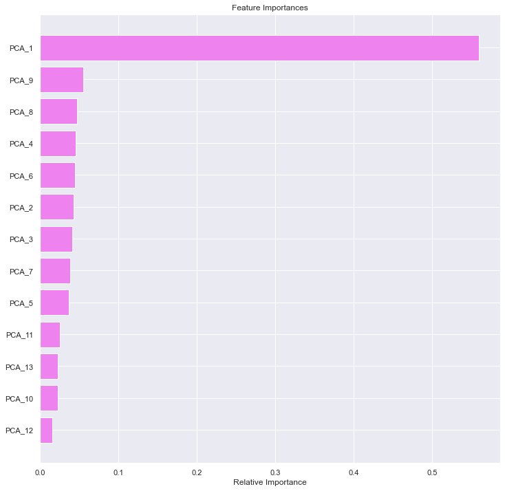

```python
#Plot Feature Importance
feature_names = X1_train.columns
importances = xgb_tuned3[1].feature_importances_
indices = np.argsort(importances)

plt.figure(figsize=(12, 12))
plt.title("Feature Importances")
plt.barh(range(len(indices)), importances[indices], color="violet", align="center")
plt.yticks(range(len(indices)), [feature_names[i] for i in indices])
plt.xlabel("Relative Importance")
plt.show()
```

**1.2.9.1 Feature Importance Conclusion**

**1.2.10 Confusion Matrix for full dataset and best model**

```python
def make_confusion_matrix3(model,y_actual,labels=[1, 0]):
    '''
    model : classifier to predict values of X
    y_actual : ground truth

    '''
    y_predict = model.predict(X1_test)
    cm=metrics.confusion_matrix( y_actual, y_predict, labels=[0, 1])
    df_cm = pd.DataFrame(cm, index = [i for i in ["Actual - No","Actual - Yes"]],
                  columns = [i for i in ['Predicted - No','Predicted - Yes']])
    group_counts = ["{0:0.0f}".format(value) for value in
                cm.flatten()]
    group_percentages = ["{0:.2%}".format(value) for value in
                         cm.flatten()/np.sum(cm)]
    labels = [f"{v1}\n{v2}" for v1, v2 in
              zip(group_counts,group_percentages)]
    labels = np.asarray(labels).reshape(2,2)
    plt.figure(figsize = (10,7))
    sns.heatmap(df_cm, annot=labels,fmt='')
    plt.ylabel('True label')
    plt.xlabel('Predicted label')
```

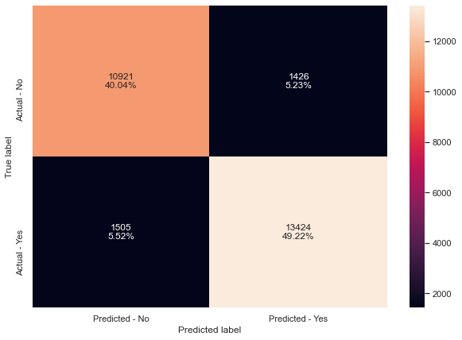

```python
# Creating confusion matrix
make_confusion_matrix3(xgb_tuned3, y1_test)
```

**1.2.11. Overall Conclusion**

**1.2.12. Reccomendation for next step**

- Used this model to pass on the dataset before PCA analysis in order to figured out feature importance from the model.
- This step was not performed due to time constraints.

```python
#Export notebook to HTML type.
import os
os.system('jupyter nbconvert --to html Capstone_Aviation_Marketing_Project_Milestone_III_.ipynb')
```

```
0
```